# 課題13(必須)

- 以下の動作をするプログラムを `OpenMP` を用いて書け。
  - 浮動小数点数(double型)の大きな配列を確保せよ。区間[0, 1)から一様に値を返す一様乱数の平方根で配列を埋めよ。
  - 大きな配列はできれば1G (=2^30)要素とせよ。ノートパソコンの搭載メモリ量に応じてこれより小さい値を使っても良い。
- 利用するスレッド数（コア数）を搭載CPUコア数まで増やしていくと実行時間がどう変化するかを調べよ。
- （必須とはしないが）できればコア数の多い、情報基盤センタースーパーコンピューターなどを用いて実験せよ。

## 手法

※ プログラムの実行時間は、`time` コマンドを用いて計測した。`time` コマンドでは以下の値を出力する。  
**（元々は`time.h` の `clock()` を利用して計測していたが、おそらく `user` の時間を出力していたので変更した。 `wallclocktime()` を利用すれば `real` の時間を出力できそう。）**

| 項目 | 意味 |
| --- | --- |
| `real` | プログラムの呼び出しから終了までにかかった実時間（秒） |
| `user` | プログラム自体の処理時間（秒）（ユーザCPU時間） |
| `sys` | プログラムを処理するために、OSが処理をした時間（秒）（システム時間） |

## 結果

以下のコマンドを入力し、実行時間を計測した。

```
$ g++ --version
>>> g++ (Homebrew GCC 9.1.0) 9.1.0
    Copyright (C) 2019 Free Software Foundation, Inc.
    This is free software; see the source for copying conditions.  There is NO
    warranty; not even for MERCHANTABILITY or FITNESS FOR A PARTICULAR PURPOSE.
$ g++ -fopenmp kadai13.cpp -o world
$ time ./world 4 30 1 kadai13.txt >> kadai13.txt 2>&1
```

※ 配列サイズは1Gで行い、プログラムは1回のみループを回した。

| スレッド数 | `real` | `user` | `sys` |
| --- | --- | --- | --- |
| 1 | 13.08 | 8.87 | 2.25 |
| 2 | 12.50 | 16.85 | 2.40 |
| 3 | 10.61 | 22.99 | 2.44 |
| 4 | 9.92 | 23.68 | 2.75 |
| 5 | 10.12 | 24.51 | 2.56 |
| 6 | 10.49 | 24.74 | 2.72 |
| 7 | 10.18 | 24.92 | 2.74 |
| 8 | 10.43 | 26.67 | 2.68 |
| 9 | 11.23 | 26.01 | 2.86 |
| 10 | 12.26 | 22.18 | 2.88 |

```python
# 以下のプログラムで取得することが可能
pts = []
with open("kadai13.txt") as f:
    for i,line in enumerate(f):
        if i%5 == 4: pts.append([i//5+1] + [line.split()[i*2] for i in range(3)])
```

```python
pts
```

```
[[1, '13.08', '8.87', '2.25'],
 [2, '12.50', '16.85', '2.40'],
 [3, '10.61', '22.99', '2.44'],
 [4, '9.92', '23.68', '2.75'],
 [5, '10.12', '24.51', '2.56'],
 [6, '10.49', '24.74', '2.72'],
 [7, '10.18', '24.92', '2.74'],
 [8, '10.43', '26.67', '2.68'],
 [9, '11.23', '26.01', '2.86'],
 [10, '12.26', '22.18', '2.88']]
```

## 可視化

```python
import numpy as np
import matplotlib.pyplot as plt
```

```python
pts = np.array(pts).astype(float)
```

```python
thread = pts[:,0]
real = pts[:,1]
user = pts[:,2]
sys  = pts[:,3]
```

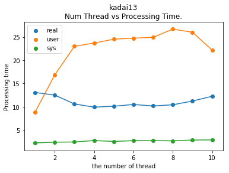

```python
plt.plot(thread, real); plt.scatter(thread, real, label="real")
plt.plot(thread, user); plt.scatter(thread, user, label="user")
plt.plot(thread, sys);  plt.scatter(thread, sys,  label="sys")
plt.xlabel("the number of thread")
plt.ylabel("Processing time")
plt.title("kadai13\nNum Thread vs Processing Time.")
plt.legend()
plt.show()
```

## 考察

上記の**real**が示す通り、スレッド数に対する実行時間の差異はほとんどなかった。この理由を考察する。

1. **`OpenMP` や `rand_r()` の使い方が間違っている**： アクティビティモニタや `top` コマンドの出力では正しくスレッド数が増えていた上、

   ```
   omp_set_num_threads(NUM_THREADS);
   #pragma omp parallel
   {
   #pragma omp for
   for(int i=0; i<10; i++){
    sleep(1);
    cout << "*" << endl;
   }
   }
   ```

   上のようなプログラムを実行したところ、綺麗に **`ceil(10/NUM_THREADS)`** の値がプログラム実行時間となっていたので、**この可能性は考えにくい。**
2. **`malloc`,`free` を用いて配列を作成することに大半の時間をかけている**： **考えにくい。**
3. **配列のアクセスをマルチスレッドで行うのが非効率**： 複数のCPU間で同じ**CPUキャッシュライン**に含まれる変数に書き込みを行うと、互いのCPUキャッシュを無効化してしまうので、効率が上がらない。今回のプログラムは書き込みの頻度が高く、また、各スレッドが担当するアドレスを以下のプログラムで調べたところ、

   ```
   omp_set_num_threads(NUM_THREADS);
   #pragma omp parallel
   {
   #pragma omp for
   for(int i=0; i<20; i++){
    int t = omp_get_thread_num();
    int s = 1*(t+1);
    sleep(s);
    cout << t << ": " << i << " " << endl;
   }
   }
   ```

   「スレッド0: i=0~6, スレッド1: i=7~13, スレッド2: i=14~19」という分け方を行っていた。 **「変数aとbを格納しているアドレスを64で割った商が同じ場合には同一キャッシュラインの上に載っている」**という性質があるそうなので、1Gサイズの配列をスレッドで分割した場合、**False Sharing が起こっていると考えられ、これが効率が上がらない原因**だと考えられる。